# MCA

Elsa Marques

12/11/2017

# 1 - Data Analysis

## 1.1 - Load data and explore data summary, dimensions and correlations

### 1.1.1 - For the overall data

```r
Hobbies <- read.table("data/hobbies_.csv", header = TRUE, sep = ",")
head(Hobbies, n = 10)
```

```
##    Read L.Music Cinema Show Exhib Comp Sport Walk Travel Play.M Collect
## 1     1       1      1    1     1    0     1    1      1      0       0
## 2     1       1      0    0     1    0     0    0      1      0       0
## 3     1       1      1    1     0    0     0    1      0      0       0
## 4     0       0      0    0     0    0     0    0      0      0       0
## 5     0       1      0    0     0    1     1    0      0      0       0
## 6     1       1      1    1     0    1     1    1      1      1       0
## 7     1       1      1    0     1    0     0    0      0      1       0
## 8     1       0      1    1     0    0     1    0      0      0       0
## 9     1       1      1    1     1    0     0    1      1      0       0
## 10    1       1      1    1     1    1     1    0      1      0       0
##    Volunteer Mech Garden Knitt Cook Fish TV Gender     Age Marital.St
## 1          1    1      0     0    0    0  2      F (55,65]    Married
## 2          0    0      0     0    0    0  4      F (25,35]  Remarried
## 3          0    0      0     0    0    0  3      M (55,65]    Married
```

[output cut: 18 more lines]

```r
summary(Hobbies)
```

```
##       Read          L.Music           Cinema            Show
##  Min.   :0.000   Min.   :0.0000   Min.   :0.0000   Min.   :0.0000
##  1st Qu.:0.000   1st Qu.:0.0000   1st Qu.:0.0000   1st Qu.:0.0000
##  Median :1.000   Median :1.0000   Median :0.0000   Median :0.0000
##  Mean   :0.672   Mean   :0.7131   Mean   :0.4012   Mean   :0.2902
##  3rd Qu.:1.000   3rd Qu.:1.0000   3rd Qu.:1.0000   3rd Qu.:1.0000
##  Max.   :1.000   Max.   :1.0000   Max.   :1.0000   Max.   :1.0000
##
##      Exhib             Comp            Sport             Walk
##  Min.   :0.0000   Min.   :0.0000   Min.   :0.0000   Min.   :0.0000
##  1st Qu.:0.0000   1st Qu.:0.0000   1st Qu.:0.0000   1st Qu.:0.0000
##  Median :0.0000   Median :0.0000   Median :0.0000   Median :1.0000
##  Mean   :0.3127   Mean   :0.3778   Mean   :0.3684   Mean   :0.5108
##  3rd Qu.:1.0000   3rd Qu.:1.0000   3rd Qu.:1.0000   3rd Qu.:1.0000
##  Max.   :1.0000   Max.   :1.0000   Max.   :1.0000   Max.   :1.0000
##
##      Travel           Play.M        Collect         Volunteer
##  Min.   :0.0000   Min.   :0.00   Min.   :0.0000   Min.   :0.0000
##  1st Qu.:0.0000   1st Qu.:0.00   1st Qu.:0.0000   1st Qu.:0.0000
##  Median :0.0000   Median :0.00   Median :0.0000   Median :0.0000
##  Mean   :0.4065   Mean   :0.17   Mean   :0.1096   Mean   :0.1571
##  3rd Qu.:1.0000   3rd Qu.:0.00   3rd Qu.:0.0000   3rd Qu.:0.0000
##  Max.   :1.0000   Max.   :1.00   Max.   :1.0000   Max.   :1.0000
##
##       Mech            Garden           Knitt             Cook
##  Min.   :0.0000   Min.   :0.0000   Min.   :0.0000   Min.   :0.0000
##  1st Qu.:0.0000   1st Qu.:0.0000   1st Qu.:0.0000   1st Qu.:0.0000
##  Median :0.0000   Median :0.0000   Median :0.0000   Median :0.0000
##  Mean   :0.4398   Mean   :0.4109   Mean   :0.1709   Mean   :0.4455
##  3rd Qu.:1.0000   3rd Qu.:1.0000   3rd Qu.:0.0000   3rd Qu.:1.0000
##  Max.   :1.0000   Max.   :1.0000   Max.   :1.0000   Max.   :1.0000
##
##       Fish              TV       Gender        Age           Marital.St
##  Min.   :0.0000   Min.   :0.00   F:3772   (45,55]:1624   Divorcee : 712
##  1st Qu.:0.0000   1st Qu.:1.00   M:3133   (35,45]:1455   Married  :3631
##  Median :0.0000   Median :2.00            (25,35]:1183   Remarried: 352
##  Mean   :0.1134   Mean   :2.37            (55,65]:1067   Single   :1609
##  3rd Qu.:0.0000   3rd Qu.:4.00            (65,75]: 713   Widower  : 601
##  Max.   :1.0000   Max.   :4.00            [15,25]: 456
##                                           (Other): 407
##                Prof          N.Act
##  Employee        :2552   Min.   : 0.00
##  Foreman         : 735   1st Qu.: 4.00
##  Management      :1052   Median : 7.00
##  Manual labourer :1161   Mean   : 6.95
##  Other           : 212   3rd Qu.: 9.00
##  Technician      : 401   Max.   :16.00
##  Unskilled worker: 792
```

### 1.1.2 - For the sub grouped data according to the type of hobbie

- Generic_Hobbies include reading (“Read”), listening to music (“L.Music”), going to the cinema (“Cinema”), using the computer (“Comp”), watching Tv (“TV”) and the four variables that define the enquired people “Gender”,“Age”, “Marital.St”, “Prof”

```r
Generic_Hobbies <- read.table("data/Generic_Hobbies.csv", header = TRUE, sep = ",")
head(Generic_Hobbies, n = 10)
```

```
##    Read L.Music Cinema Comp TV Gender     Age Marital.St            Prof
## 1     1       1      1    0  2      F (55,65]    Married      Management
## 2     1       1      0    0  4      F (25,35]  Remarried      Management
## 3     1       1      1    0  3      M (55,65]    Married        Employee
## 4     0       0      0    0  3      M (45,55]    Married Manual labourer
## 5     0       1      0    1  3      M (35,45]    Married        Employee
## 6     1       1      1    1  1      F (35,45]     Single      Management
## 7     1       1      1    0  1      F (25,35]     Single        Employee
## 8     1       0      1    0  0      F [15,25]     Single        Employee
## 9     1       1      1    0  2      F (75,85]   Divorcee      Management
## 10    1       1      1    1  3      F (35,45]    Married        Employee
```

```r
summary(Generic_Hobbies)
```

```
##       Read          L.Music           Cinema            Comp
##  Min.   :0.000   Min.   :0.0000   Min.   :0.0000   Min.   :0.0000
##  1st Qu.:0.000   1st Qu.:0.0000   1st Qu.:0.0000   1st Qu.:0.0000
##  Median :1.000   Median :1.0000   Median :0.0000   Median :0.0000
##  Mean   :0.672   Mean   :0.7131   Mean   :0.4012   Mean   :0.3778
##  3rd Qu.:1.000   3rd Qu.:1.0000   3rd Qu.:1.0000   3rd Qu.:1.0000
##  Max.   :1.000   Max.   :1.0000   Max.   :1.0000   Max.   :1.0000
##
##        TV       Gender        Age           Marital.St
##  Min.   :0.00   F:3772   (45,55]:1624   Divorcee : 712
##  1st Qu.:1.00   M:3133   (35,45]:1455   Married  :3631
##  Median :2.00            (25,35]:1183   Remarried: 352
##  Mean   :2.37            (55,65]:1067   Single   :1609
##  3rd Qu.:4.00            (65,75]: 713   Widower  : 601
##  Max.   :4.00            [15,25]: 456
##                          (Other): 407
##                Prof
##  Employee        :2552
##  Foreman         : 735
##  Management      :1052
##  Manual labourer :1161
##  Other           : 212
##  Technician      : 401
##  Unskilled worker: 792
```

- Artistic_Hobbies include attending shows (“Show”), exhibitions (“Exhib”), playing music (“Play.M”), collectionist (“Collect”), and the four variables that define the enquired people “Gender”,“Age”, “Marital.St”, “Prof”

```r
Artistic_Hobbies <- read.table("data/Artistic_Hobbies.csv", header = TRUE, sep = ",")
head(Artistic_Hobbies, n = 10)
```

```
##    Show Exhib Play.M Collect Gender     Age Marital.St            Prof
## 1     1     1      0       0      F (55,65]    Married      Management
## 2     0     1      0       0      F (25,35]  Remarried      Management
## 3     1     0      0       0      M (55,65]    Married        Employee
## 4     0     0      0       0      M (45,55]    Married Manual labourer
## 5     0     0      0       0      M (35,45]    Married        Employee
## 6     1     0      1       0      F (35,45]     Single      Management
## 7     0     1      1       0      F (25,35]     Single        Employee
## 8     1     0      0       0      F [15,25]     Single        Employee
## 9     1     1      0       0      F (75,85]   Divorcee      Management
## 10    1     1      0       0      F (35,45]    Married        Employee
```

```r
summary(Artistic_Hobbies)
```

```
##       Show            Exhib            Play.M        Collect
##  Min.   :0.0000   Min.   :0.0000   Min.   :0.00   Min.   :0.0000
##  1st Qu.:0.0000   1st Qu.:0.0000   1st Qu.:0.00   1st Qu.:0.0000
##  Median :0.0000   Median :0.0000   Median :0.00   Median :0.0000
##  Mean   :0.2902   Mean   :0.3127   Mean   :0.17   Mean   :0.1096
##  3rd Qu.:1.0000   3rd Qu.:1.0000   3rd Qu.:0.00   3rd Qu.:0.0000
##  Max.   :1.0000   Max.   :1.0000   Max.   :1.00   Max.   :1.0000
##
##  Gender        Age           Marital.St                 Prof
##  F:3772   (45,55]:1624   Divorcee : 712   Employee        :2552
##  M:3133   (35,45]:1455   Married  :3631   Foreman         : 735
##           (25,35]:1183   Remarried: 352   Management      :1052
##           (55,65]:1067   Single   :1609   Manual labourer :1161
##           (65,75]: 713   Widower  : 601   Other           : 212
##           [15,25]: 456                    Technician      : 401
##           (Other): 407                    Unskilled worker: 792
```

- Handcraft_Hobbies include mechanics (“Mech”), gardening (“Garden”), knitting (“Knitt”), cooking (“Cook”) and the four variables that define the enquired people “Gender”,“Age”, “Marital.St”, “Prof”.

```r
Handcraft_Hobbies <- read.table("data/Handcraft_Hobbies.csv" , header = TRUE, sep = ",")
head(Handcraft_Hobbies, n = 10)
```

```
##    Mech Garden Knitt Cook Gender     Age Marital.St            Prof
## 1     1      0     0    0      F (55,65]    Married      Management
## 2     0      0     0    0      F (25,35]  Remarried      Management
## 3     0      0     0    0      M (55,65]    Married        Employee
## 4     1      0     0    0      M (45,55]    Married Manual labourer
## 5     1      0     0    0      M (35,45]    Married        Employee
## 6     0      0     0    0      F (35,45]     Single      Management
## 7     1      1     0    0      F (25,35]     Single        Employee
## 8     0      0     0    0      F [15,25]     Single        Employee
## 9     0      0     0    0      F (75,85]   Divorcee      Management
## 10    0      0     0    0      F (35,45]    Married        Employee
```

```r
summary(Handcraft_Hobbies)
```

```
##       Mech            Garden           Knitt             Cook
##  Min.   :0.0000   Min.   :0.0000   Min.   :0.0000   Min.   :0.0000
##  1st Qu.:0.0000   1st Qu.:0.0000   1st Qu.:0.0000   1st Qu.:0.0000
##  Median :0.0000   Median :0.0000   Median :0.0000   Median :0.0000
##  Mean   :0.4398   Mean   :0.4109   Mean   :0.1709   Mean   :0.4455
##  3rd Qu.:1.0000   3rd Qu.:1.0000   3rd Qu.:0.0000   3rd Qu.:1.0000
##  Max.   :1.0000   Max.   :1.0000   Max.   :1.0000   Max.   :1.0000
##
##  Gender        Age           Marital.St                 Prof
##  F:3772   (45,55]:1624   Divorcee : 712   Employee        :2552
##  M:3133   (35,45]:1455   Married  :3631   Foreman         : 735
##           (25,35]:1183   Remarried: 352   Management      :1052
##           (55,65]:1067   Single   :1609   Manual labourer :1161
##           (65,75]: 713   Widower  : 601   Other           : 212
##           [15,25]: 456                    Technician      : 401
##           (Other): 407                    Unskilled worker: 792
```

- Sport_Hobbies include the general sports answer (“Sport”), walking (“Walk”) , traveling (“Travel”), fishing (“Fish”), and the four variables that define the enquired people “Gender”,“Age”, “Marital.St”, “Prof”

```r
Sport_Hobbies <- read.table("data/Sport_Hobbies.csv",  header = TRUE, sep = ",")
head(Sport_Hobbies, n = 10)
```

```
##    Sport Walk Travel Fish Gender     Age Marital.St            Prof
## 1      1    1      1    0      F (55,65]    Married      Management
## 2      0    0      1    0      F (25,35]  Remarried      Management
## 3      0    1      0    0      M (55,65]    Married        Employee
## 4      0    0      0    0      M (45,55]    Married Manual labourer
## 5      1    0      0    0      M (35,45]    Married        Employee
## 6      1    1      1    0      F (35,45]     Single      Management
## 7      0    0      0    0      F (25,35]     Single        Employee
## 8      1    0      0    0      F [15,25]     Single        Employee
## 9      0    1      1    0      F (75,85]   Divorcee      Management
## 10     1    0      1    0      F (35,45]    Married        Employee
```

```r
summary(Sport_Hobbies)
```

```
##      Sport             Walk            Travel            Fish
##  Min.   :0.0000   Min.   :0.0000   Min.   :0.0000   Min.   :0.0000
##  1st Qu.:0.0000   1st Qu.:0.0000   1st Qu.:0.0000   1st Qu.:0.0000
##  Median :0.0000   Median :1.0000   Median :0.0000   Median :0.0000
##  Mean   :0.3684   Mean   :0.5108   Mean   :0.4065   Mean   :0.1134
##  3rd Qu.:1.0000   3rd Qu.:1.0000   3rd Qu.:1.0000   3rd Qu.:0.0000
##  Max.   :1.0000   Max.   :1.0000   Max.   :1.0000   Max.   :1.0000
##
##  Gender        Age           Marital.St                 Prof
##  F:3772   (45,55]:1624   Divorcee : 712   Employee        :2552
##  M:3133   (35,45]:1455   Married  :3631   Foreman         : 735
##           (25,35]:1183   Remarried: 352   Management      :1052
##           (55,65]:1067   Single   :1609   Manual labourer :1161
##           (65,75]: 713   Widower  : 601   Other           : 212
##           [15,25]: 456                    Technician      : 401
##           (Other): 407                    Unskilled worker: 792
```

- Charity_Hobbies include volunttering (“Volunteer”), and the four variables that define the enquired people “Gender”,“Age”, “Marital.St”, “Prof”

```r
Charity_Hobbies <- read.table("data/Charity_hobbies.csv",  header = TRUE, sep = ",")
head(Charity_Hobbies, n = 10)
```

```
##    Volunteer Gender     Age Marital.St            Prof
## 1          1      F (55,65]    Married      Management
## 2          0      F (25,35]  Remarried      Management
## 3          0      M (55,65]    Married        Employee
## 4          0      M (45,55]    Married Manual labourer
## 5          0      M (35,45]    Married        Employee
## 6          0      F (35,45]     Single      Management
## 7          0      F (25,35]     Single        Employee
## 8          0      F [15,25]     Single        Employee
## 9          0      F (75,85]   Divorcee      Management
## 10         0      F (35,45]    Married        Employee
```

```r
summary(Charity_Hobbies)
```

```
##    Volunteer      Gender        Age           Marital.St
##  Min.   :0.0000   F:3772   (45,55]:1624   Divorcee : 712
##  1st Qu.:0.0000   M:3133   (35,45]:1455   Married  :3631
##  Median :0.0000            (25,35]:1183   Remarried: 352
##  Mean   :0.1571            (55,65]:1067   Single   :1609
##  3rd Qu.:0.0000            (65,75]: 713   Widower  : 601
##  Max.   :1.0000            [15,25]: 456
##                            (Other): 407
##                Prof
##  Employee        :2552
##  Foreman         : 735
##  Management      :1052
##  Manual labourer :1161
##  Other           : 212
##  Technician      : 401
##  Unskilled worker: 792
```

- Let’s attempt to have an overview on how the totality of the data correlats with each other:

[figure not shown]

```r
# Draw the plot
library(GGally)
library(ggplot2)
ggpairs(Hobbies, mapping = aes(col = Gender, alpha = 0.3), lower = list(combo = wrap("facethist", bins = 20))) + theme_bw() + theme(axis.text.x=element_text(angle = -90, hjust = 0))
```

- Clearly observing this plot will not highlith much of the data, so lets try the same with the subsets defined previously:
- **Generic_Hobbies**

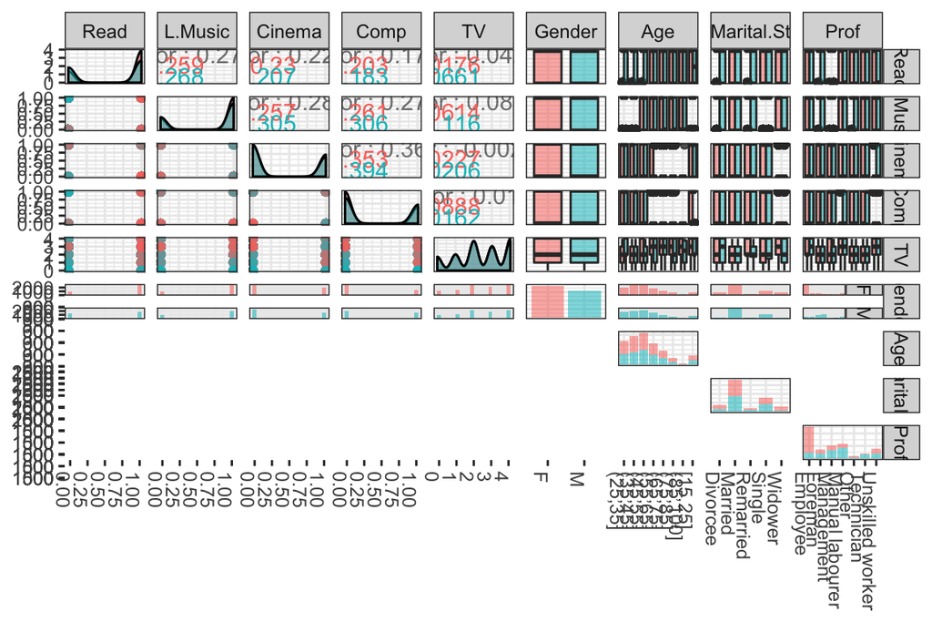

```r
ggpairs(Generic_Hobbies, mapping = aes(col = Gender, alpha = 0.3), lower = list(combo = wrap("facethist", bins = 20))) + theme_bw() + theme(axis.text.x=element_text(angle = -90, hjust = 0))
```

- It seems no significant differences can be observe by gender. There might be a sligh higher number of females that answered reading and even a less dramatic increase in the listening music. When it comes to computes the same slight increase in the females that said that computers are not were they spend their hobbies time. No differences can be pointed out when it comes to watching TV or going to the cinema.
- When it comes to the age effect in this variable, you can verufy that females from 25 - 55 tens to read less as a hobbie. Surprisingly when it comes to listening music in the ages from 15 - 45 seems to be a less popular hobbie in both genders. When it comes to going to the cinema, from 55 tp 100 it seems its not a very popular hobbie in any of the genders (exception for the females from 55-65). When it comes to watching TV it seems that after 45years old both gender average of time dedicated to this increases.
- Marital Status also doesn’t seem to affect the amount of watched TV by the enquired. But Widowers seem to spend less time in the computer or going to the movies (both genders). When it comes to reading, it seems only Remarried and Divorced females don’t use it as a hobbie. Single females and males seem not to listen music as a hobbie, same as remarried and divorced females.
- Professions also don’t seem to affect that much the average amount of TV watched. When it comes to time spent in computer, unskilled (both genders) and manual (female) work used it less as a hobbie as the other professions. Reading it’s not a popular hobbie amongs female foreman and amongst both genders doing manual work. Same pattern is observed for Listening Music with the adiction of the females enquired that answered other profession. Cinema seems an all professions hobbie with the exception of the females practicing unskilled work.
- **Artistic_Hobbies**

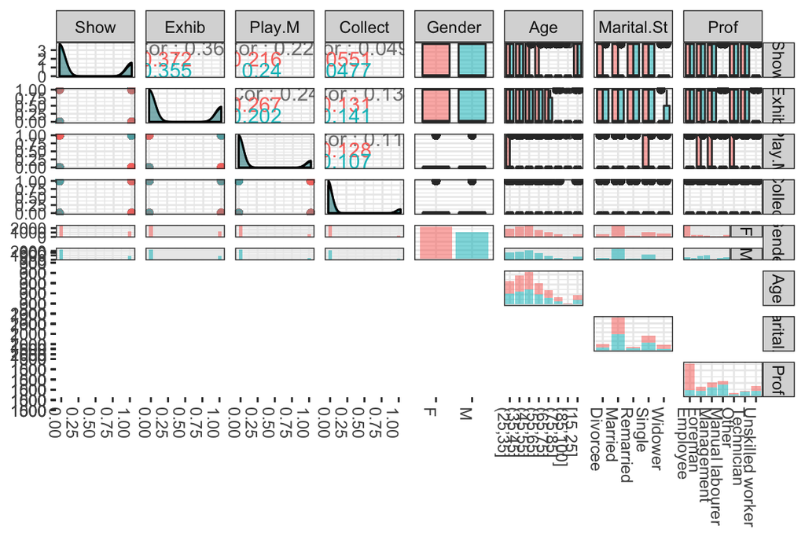

```r
ggpairs(Artistic_Hobbies, mapping = aes(col = Gender, alpha = 0.3), lower = list(combo = wrap("facethist", bins = 20))) + theme_bw() + theme(axis.text.x=element_text(angle = -90, hjust = 0))
```

- Also in the Artistic category it seems that we cannot identify a clear trend in any of the activities comparing Genders. There might be a sligh higher number of female that answered that have as hoobies attending to shows, exhibitions, collectionist and playing music.
- As for the age it seems that after 45 males have a dramatic drop in attending show , while that happens for females after 55. Attending exhibitons suffered a dramatic drop after 65 for both genders. Playing music and collectionist seems not to highly affect by the age of the enquired. Noticeable only that females in the 25 - 35 are the ones answering more that they practice playing music as hobbie.
- If we look at the marital status it seems widower (both genders) are the ones that never attend to shows and only males answered they attend exhibitions. Only female single seem to answer they play music as a hobbie.
- As for the profession , unskilled and manual labourer profession don’t tend to participate in any of the hobbies included in this artistic category. As for the other professions only females answered they frequently atten shows, exhibitions and play music. None of these enquired professions seems to be related with collectionism.
- **Handcraft_Hobbies**